# Figure 4

2024-09-26

# Load packages

```r
# Install packages
req_pkgs <- c("data.table", "stringr", "ggpubr", "rehh", "vcfR", "patchwork", "grid")
for(pkg in req_pkgs){
    if(!require(pkg, character.only=TRUE)){install.packages(pkg); library(pkg, character.only=TRUE)}
}
```

# Load annotations

```r
bed_fn <- "results/bcf_pipe/call/drum.hi_dep_region.bed"
bed_d <- fread(bed_fn, header=FALSE, col.names=c("CHROM", "START", "END"))

gene_fn <- "annot/R2R3Myb.gene.bed"
gene_d <- fread(gene_fn, header=FALSE, col.names=c("CHROM", "START", "END", "ELEMENT"))

snp_fn <- "annot/R2R3Myb.putative_snp.pos"
snp_pos <- as.numeric(fread(snp_fn, header=FALSE)$V1)
```

# Load metadata

```r
met_d <- fread("config/drum.metadata.tsv", header=TRUE, sep="\t")
```

# LD Data

Load pairwise LD data. This can take some time (and requires a sizable chunk of memory) due to all the pairwise comparisons. Provided some code for saving the post-processed results as an Rdata object to save time for future runs.

```r
ld_prefix <- "results/pairwise_ld/merged.drum.filt.lmiss_0.5.imiss_0.9.polarized.bi_ld"
md5str <- system(str_interp("md5sum ${ld_prefix}.ld | cut -f 1 -d ' '"), intern = TRUE)
ld_rdat <- str_interp("${ld_prefix}.${md5str}.RData")
if(file.exists(ld_rdat)){
    load(ld_rdat)
} else {
    snp_dat <- fread(str_interp("${ld_prefix}.frq.counts"), header=TRUE)
    snp_dat[, POS := as.numeric(tstrsplit(SNP, ":")[[2]])]
    snp_dat[, INDEX := .I]

    # Ensure only variable sites
    snp_dat <- snp_dat[C1 != 0]
    keep_i <- snp_dat[,INDEX]

    rsq_mat <- fread(str_interp("${ld_prefix}.ld"), header=FALSE, sep="\t", na.strings="nan", select=keep_i)
    rsq_mat <- as.matrix(rsq_mat[keep_i])

    rownames(rsq_mat) <- snp_dat[, str_c("P", POS)]
    colnames(rsq_mat) <- rownames(rsq_mat)
}
```

To simplify things, let’s aggregate the data by taking mean R^2 every 50 bp

Note that the `AggregateRsq` function computes multiple summary stats but we’ll just be plotting arithmetic mean.

```r
if(!("ld_aggr" %in% ls())){
    binwidth <- 50
    breaks <- bed_d[, seq(START, END, by=binwidth)]
    breaks <- breaks[1:(max(which(breaks < gene_d[, max(END)])) + 1)]
    bins <- (breaks[-length(breaks)] + breaks[-1]) / 2
    nbins <- length(bins)

    snp_dat[, BIN_INDEX := as.integer(cut(POS, breaks=breaks, labels=bins))]
    snp_dat[, RN := .I]
    setkey(snp_dat, BIN_INDEX)


    ld_aggr <- data.table(BIN_I_X = unlist(sapply(1:nbins, function(x) rep(x, nbins - x + 1))),
                        BIN_I_Y = unlist(sapply(1:nbins, function(x) x:nbins)))

    AggregateRsq <- function(bin_x, bin_y){
        rn <- snp_dat[.(bin_x), RN]
        cn <- snp_dat[.(bin_y), RN]
        cur_vals <- rsq_mat[rn, cn]

        if(all(is.na(cur_vals))){
            out_list <- list(NA, NA, NA, NA)
        } else {
            min_val <- min(cur_vals, na.rm=TRUE)
            max_val <- max(cur_vals, na.rm=TRUE)
            med_val <- median(cur_vals, na.rm=TRUE)
            mean_val <- mean(cur_vals, na.rm=TRUE)
            out_list <- list(min_val, max_val, med_val, mean_val)
        }

        return(out_list)
    }

    ld_aggr[, INDEX := .I]
    uniq_bin_index <- snp_dat[, unique(BIN_INDEX)]

    ld_aggr[  (BIN_I_X %in% uniq_bin_index) & (BIN_I_Y %in% uniq_bin_index),
            c("MIN", "MAX", "MED", "MEAN") := AggregateRsq(BIN_I_X, BIN_I_Y),
            by=INDEX]

    ld_aggr[, POS_X := bins[BIN_I_X]]
    ld_aggr[, POS_Y := bins[BIN_I_Y]]

    save(ld_aggr, binwidth, file=ld_rdat)
}
```

# Haplotype data

## Load haplotype data

Load haplotypes. Note that we load the data twice, once with `polarize_vcf = TRUE` for EHH analyses + F&W’s H and once with `polarize_vcf = FALSE` for Tajima’s D analyses. This allows us to retain maximal data since `polarize_vcf = TRUE` drops data without any ancestral allele annotation (`INFO/AA` field) and this information is not necessary for our Tajima’s D analyses.

```r
vcf_fn <- "results/snp_postproc/merged.drum.filt.lmiss_0.5.imiss_0.9.polarized.phased.vcf.gz"
hh <- list()
for(a in c("T", "F")){
    hh[[a]] <- data2haplohh( hap_file = vcf_fn,
                            vcf_reader = "vcfR",
                            polarize_vcf = (a == "T"),
                            verbose = TRUE,
                            min_perc_geno.mrk = 50)
}
```

[output not shown]

```
## Extracting haplotypes.
## Number of individuals which are
## Haploid Diploid Triploid, ... :
## 1 2
## 0 107
## No marker identifiers found in vcf file.
## Polarizing variants.
## 12584 markers have been polarized.
## 22313 unpolarized markers have been removed.
## * Filtering data *
## Discard markers genotyped on less than 50 % of haplotypes.
## No marker discarded.
## Data consists of 214 haplotypes and 12584 markers.
## Number of mono-, bi-, multi-allelic markers:
## 1 2 3 4
## 9757 2470 333 24
## * Reading input file(s) *
## Using package 'vcfR' to read vcf.
## Extracting map information.
## Scanning file to determine attributes.
## File attributes:
##   meta lines: 21107
##   header_line: 21108
##   variant count: 34897
##   column count: 116
## Meta line 1000 read in.Meta line 2000 read in.Meta line 3000 read in.Meta line 4000 read in.Meta line 5000 read in.Meta line 6000 read in.Meta line 7000 read in.Meta line 8000 read in.Meta line 9000 read in.Meta line 10000 read in.Meta line 11000 read in.Meta line 12000 read in.Meta line 13000 re…
## All meta lines processed.
## gt matrix initialized.
## Character matrix gt created.
##   Character matrix gt rows: 34897
##   Character matrix gt cols: 116
##   skip: 0
##   nrows: 34897
##   row_num: 0
## Processed variant 1000Processed variant 2000Processed variant 3000Processed variant 4000Processed variant 5000Processed variant 6000Processed variant 7000Processed variant 8000Processed variant 9000Processed variant 10000Processed variant 11000Processed variant 12000Processed variant 13000Process…
## All variants processed
## Extracting haplotypes.
## Number of individuals which are
## Haploid Diploid Triploid, ... :
## 1 2
## 0 107
## No marker identifiers found in vcf file.
## * Filtering data *
## Discard markers genotyped on less than 50 % of haplotypes.
## No marker discarded.
## Data consists of 214 haplotypes and 34897 markers.
## Number of mono-, bi-, multi-allelic markers:
## 1 2 3 4
## 25012 8353 1431 101
```

```r
# Keep metadata on samples that are in vcf
keep_samps <- str_remove(rownames(hh[["T"]]@haplo)[(1:nrow(hh[["T"]]@haplo)) %% 2 == 1], "_1$")
met_d <- met_d[Individual %in% keep_samps]
```

Break haplotype data down by subregion. First create a function for subsetting haplotypes by samples

```r
SubsetHaplo <- function(in_hh, sampnames, ...){
    hnames <- str_c(rep(sampnames, 2), c(rep("_1", length(sampnames)), rep("_2", length(sampnames))))
    keep_rows <- which(rownames(in_hh@haplo) %in% hnames)
    return(subset(in_hh, select.hap=keep_rows, ...))
}
```

Now let’s look at each subregion in isolation …

```r
hh_sub <- list()
for(a in names(hh)){
    hh_sub[[a]] <- list()
    for(reg in c(unique(met_d$region), "symp_allo")){
        if(reg == "symp_allo"){
            keep_samps <- met_d[region %in% c("Sympatry", "Allopatry"), Individual]
        } else {
            keep_samps <- met_d[region == reg, Individual]
        }

        hh_sub[[a]][[reg]] <- SubsetHaplo(hh[[a]], sampnames=keep_samps, min_perc_geno.mrk=50)
    }
}
```

```
## * Subset haplotypes *
## 136 haplotypes discarded.
## 78 haplotypes remaining.
## * Filtering data *
## Discard markers genotyped on less than 50 % of haplotypes.
## No marker discarded.
## Data consists of 78 haplotypes and 12584 markers.
## Number of mono-, bi-, multi-allelic markers:
## 1 2 3 4
## 11051 1415 114 4
## * Subset haplotypes *
## 180 haplotypes discarded.
## 34 haplotypes remaining.
## * Filtering data *
## Discard markers genotyped on less than 50 % of haplotypes.
## 1 markers discarded.
## 12583 markers remaining.
## Data consists of 34 haplotypes and 12583 markers.
## Number of mono-, bi-, multi-allelic markers:
## 1 2 3 4
## 11676 869 37 1
## * Subset haplotypes *
## 136 haplotypes discarded.
## 78 haplotypes remaining.
## * Filtering data *
## Discard markers genotyped on less than 50 % of haplotypes.
## 2 markers discarded.
## 12582 markers remaining.
## Data consists of 78 haplotypes and 12582 markers.
## Number of mono-, bi-, multi-allelic markers:
## 1 2 3 4
## 10717 1744 114 7
## * Subset haplotypes *
## 190 haplotypes discarded.
## 24 haplotypes remaining.
## * Filtering data *
## Discard markers genotyped on less than 50 % of haplotypes.
## No marker discarded.
## Data consists of 24 haplotypes and 12584 markers.
## Number of mono-, bi-, multi-allelic markers:
```

[output cut: 52 more lines]

```
## Data consists of 24 haplotypes and 34666 markers.
## Number of mono-, bi-, multi-allelic markers:
## 1 2 3 4
## 31410 3093 161 2
## * Subset haplotypes *
## 156 haplotypes discarded.
## 58 haplotypes remaining.
## * Filtering data *
## Discard markers genotyped on less than 50 % of haplotypes.
## 15 markers discarded.
## 34882 markers remaining.
## Data consists of 58 haplotypes and 34882 markers.
## Number of mono-, bi-, multi-allelic markers:
## 1 2 3 4
## 29819 4679 366 18
```

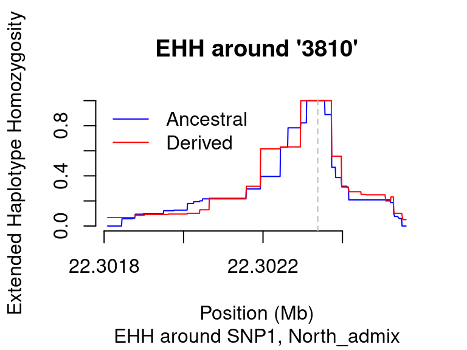

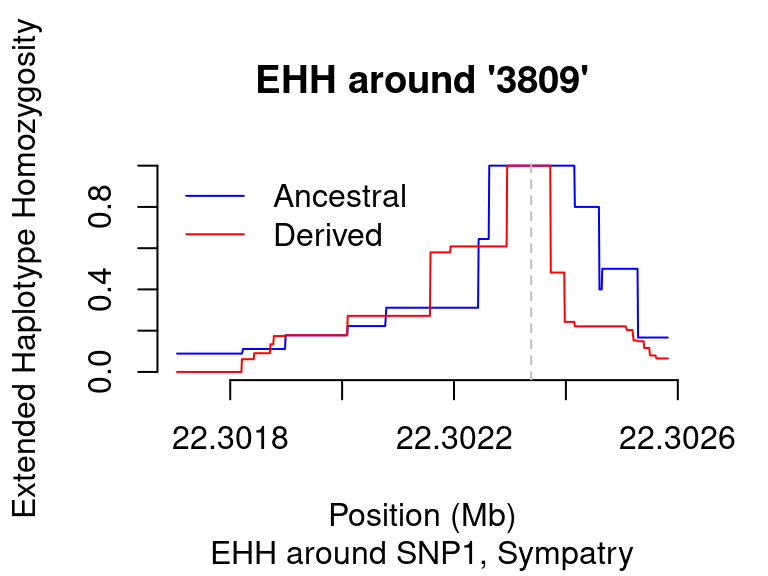

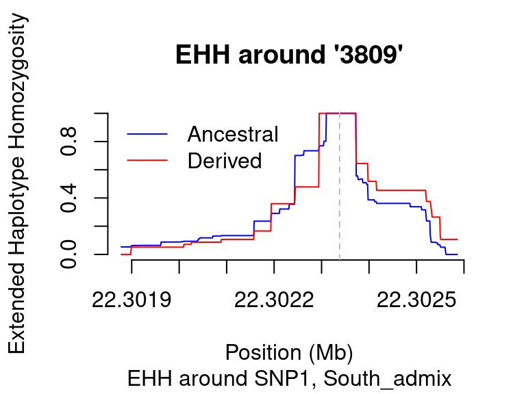

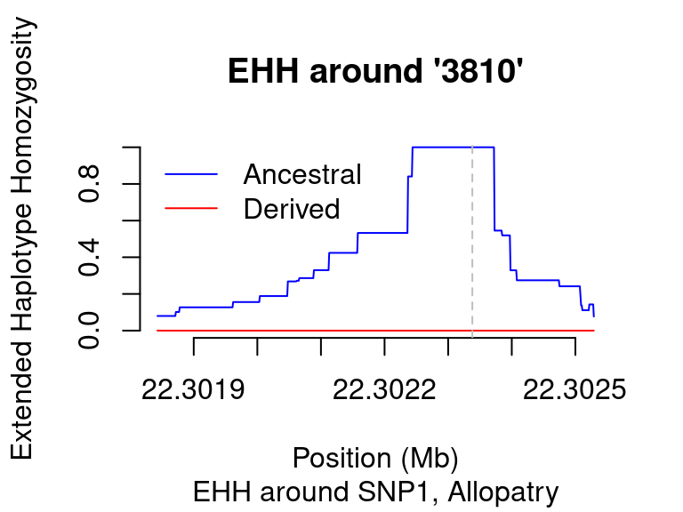

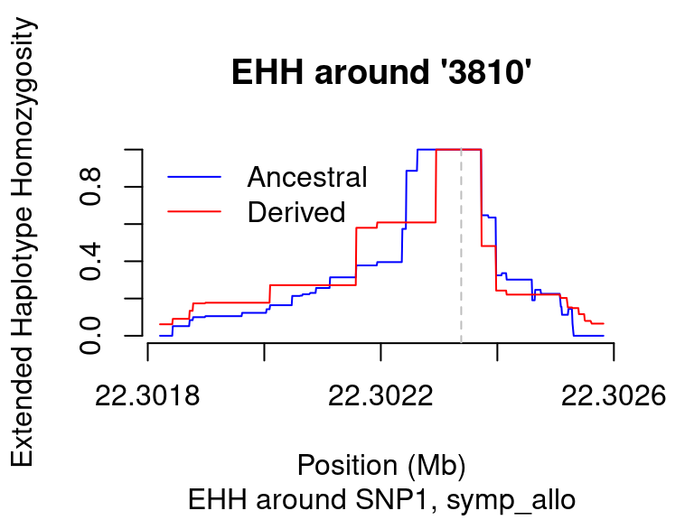

```r
scan_sub <- list()
# ihs_sub <- list()
ehh_sub <- list()
for(reg in names(hh_sub[["T"]])){
    scan_sub[[reg]] <- scan_hh(hh_sub[["T"]][[reg]], discard_integration_at_border = FALSE)
    # ihs_sub[[reg]] <- ihh2ihs(scan_sub[[reg]], verbose=TRUE, freqbin=4)

    ehh_sub[[reg]] <- calc_ehh(hh_sub[["T"]][[reg]], mrk=which(hh_sub[["T"]][[reg]]@positions == snp_pos), include_nhaplo=TRUE)
    plot(ehh_sub[[reg]])
    title(sub=str_interp("EHH around SNP1, ${reg}"))
}
```

## Process haplotype data

### XP-EHH (Cross-population EHH) Sympatry vs Allopatry

```r
xpehh_sym_allo <- ies2xpehh(scan_pop1 = scan_sub[["Sympatry"]],
                            scan_pop2 = scan_sub[["Allopatry"]],
                            popname1 = "SYMP",
                            popname2 = "ALLO")
```

```
## Scan of pop1 contains 12583 markers.
## Scan of pop2 contains 12584 markers.
## Merged data contains 12583 markers.
```

```r
xpehh_sym_allo <- as.data.table(xpehh_sym_allo)

# ID outliers
cr2 <- calc_candidate_regions(xpehh_sym_allo, threshold = 2, ignore_sign = TRUE, window_size = 1)
```

### SFS tests

Calculate SFS tests

```r
# Calculate SFS for different regions
sfs_res <- list()

for(a in names(hh)){
    sfs_res[[a]] <- list()
    # Get biallelic SNPs only
    # hh_bi <- SubsetHaplo(hh[[a]], met_d$Individual, max_alleles=2, min_perc_geno.mrk=50)
    # sfs_res[[a]][["all"]] <- as.data.table(calc_sfs_tests(hh_bi, polarized=(a == "T"), window_size=500, overlap=250, verbose=TRUE))
    # sfs_res[[a]][["all"]][N_MRK == 0, c("TAJIMA_D", "FAY_WU_H") := list(NA, NA)]
    for(reg in names(hh_sub[[a]])){
        sfs_res[[a]][[reg]] <- as.data.table(calc_sfs_tests(hh_sub[[a]][[reg]], polarized=(a == "T"), window_size=500, overlap=250, verbose=TRUE))
        sfs_res[[a]][[reg]][N_MRK == 0, c("TAJIMA_D", "FAY_WU_H") := list(NA, NA)]
    }
}
```

```
## * Filtering data *
## Discard markers genotyped on less than 2 % of haplotypes.
## No marker discarded.
## Discard markers with more than 2 different alleles.
## 118 markers discarded.
## 12466 markers remaining.
## Data consists of 78 haplotypes and 12466 markers.
## Number of mono-, bi-, multi-allelic markers:
## 1 2
## 11051 1415
## * Filtering data *
## Discard markers genotyped on less than 5 % of haplotypes.
## No marker discarded.
## Discard markers with more than 2 different alleles.
## 38 markers discarded.
## 12545 markers remaining.
## Data consists of 34 haplotypes and 12545 markers.
## Number of mono-, bi-, multi-allelic markers:
## 1 2
## 11676 869
## * Filtering data *
## Discard markers genotyped on less than 2 % of haplotypes.
## No marker discarded.
## Discard markers with more than 2 different alleles.
## 121 markers discarded.
## 12461 markers remaining.
## Data consists of 78 haplotypes and 12461 markers.
## Number of mono-, bi-, multi-allelic markers:
## 1 2
## 10717 1744
## * Filtering data *
## Discard markers genotyped on less than 8 % of haplotypes.
## No marker discarded.
## Discard markers with more than 2 different alleles.
## 40 markers discarded.
## 12544 markers remaining.
## Data consists of 24 haplotypes and 12544 markers.
## Number of mono-, bi-, multi-allelic markers:
## 1 2
## 11686 858
```

[output cut: 45 more lines]

```
## 34503 markers remaining.
## Data consists of 24 haplotypes and 34503 markers.
## Number of mono-, bi-, multi-allelic markers:
## 1 2
## 31410 3093
## * Filtering data *
## Discard markers genotyped on less than 3 % of haplotypes.
## No marker discarded.
## Discard markers with more than 2 different alleles.
## 384 markers discarded.
## 34498 markers remaining.
## Data consists of 58 haplotypes and 34498 markers.
## Number of mono-, bi-, multi-allelic markers:
## 1 2
## 29819 4679
```

# Pi, Fst Data

## Load pi and fst data

These results were calculated using pixy

```r
keep_pops <- c("Allopatry", "Sympatry", "cusp")
grp <- "region"

pixy_statnames <- c("pi"="avg_pi", "fst"="avg_wc_fst")

pixy_d <- list()
for(x in names(pixy_statnames)){
    fn <- str_interp("results/pixy/pixy.${grp}_${x}.txt")
    pixy_d[[x]] <- fread(fn, header=TRUE, sep="\t")
    if(x == "fst"){
        pixy_d[[x]] <- pixy_d[[x]][pop1 %in% keep_pops & pop2 %in% keep_pops]
    } else {
        pixy_d[[x]] <- pixy_d[[x]][pop %in% keep_pops]
    }
    setnames(pixy_d[[x]], c("window_pos_1", "window_pos_2"), c("START", "END"))
    pixy_d[[x]][, chr_position := (START + END) / 2]
}

# Set data values to NA
pixy_miss <- list()
for(p in keep_pops){
    fn <- str_interp("results/pixy/pixy.${grp}.NS_${p}.bed")
    tmp <- fread(fn, header=FALSE, sep="\t", col.names=c("CHROM", "START", "END", "NS"))
    miss_start <- tmp[NS == 0, START]
    for(x in names(pixy_statnames)){
        statnm <- pixy_statnames[x]
        if(x == "pi"){
            pixy_d[[x]][(pop == p) & (START %in% miss_start), eval(statnm) := NA]
        } else {
            pixy_d[[x]][(pop1 == p | pop2 == p) & (START %in% miss_start), eval(statnm) := NA]
        }
    }
}
```

# Build subbplots

We have a number of subbplots to put together into a final figure

## Plotting functions

```r
ScaleCoordinate <- function(x, u=1e6, from_snp=FALSE){
    # x: Unscaled chromosomal positions
    if(from_snp){
        # Convert to units relative to snp position
        y <- snp_pos - x
    } else {
        y <- x
    }
    y <- y / u
    return(y)
}

AnnotateStdDev <- function(p, y=2){
    p <- p +
        geom_hline(yintercept = y, color = "gray40", linetype = "dashed") +
        geom_hline(yintercept = -y, color = "gray40", linetype = "dashed") +
        geom_hline(yintercept = 0, color = "black", linetype = "dotted")
    return(p)
}

AnnotateGene <- function(p, y=-2.98, w=3.5, snp_only=FALSE, exon_col="black", ...){
    # y: exon position along y-axis
    # u: units on x-axis (default 1 Mb)
    # Annotate snp
    p <- p +
        geom_vline(xintercept = ScaleCoordinate(snp_pos, ...), color = "red", linetype = "dashed")

    # Annotate exons
    if(!snp_only){
        xx <- ScaleCoordinate(gene_d[str_starts(ELEMENT, "exon"), c(min(START), max(END))], ...)
        p <- p + annotate(geom="segment",
                    x=xx[1], y=y,
                    xend=xx[2], yend=y,
                    size=w/7, color=exon_col)

        for(elem in gene_d$ELEMENT){
            if(str_starts(elem, "exon")){
                xx <- ScaleCoordinate(gene_d[ELEMENT == elem, c(START+1, END)], ...)
                p <- p +
                    annotate(geom="segment",
                        x = xx, y = y,
                        xend = xx[2], yend = y,
                        size = w, color = exon_col)
            }
        }
    }
    return(p)
}

GroupLines <- function(x){
    # Assumes data is already sorted
    na_data <- is.na(x) | is.null(x)

    grp_ends <- which(na_data) - 1
    grp_ends <- grp_ends[grp_ends > 1]
    grp_ends <- grp_ends[!na_data[grp_ends]]

    grp_starts <- which(na_data) + 1
    grp_starts <- grp_starts[grp_starts < length(na_data)]
    grp_starts <- grp_starts[!na_data[grp_starts]]

   if(!na_data[1]){
        grp_starts <- c(1, grp_starts)
    }
    if(!na_data[length(na_data)]){
        grp_ends <- c(grp_ends, length(na_data))
    }

    out_val <- rep(as.integer(NA), length(na_data))
    for(i in seq_along(grp_starts)){
        out_val[grp_starts[i]:grp_ends[i]] <- as.integer(i)
    }
    return(out_val)
}
```

## Plotting parameters

```r
plt_x_from_snp <- TRUE
plt_x_units <- ifelse(plt_x_from_snp, 1e3, 1e6)
plt_xlim <- ScaleCoordinate(c(22.295e6, 22.305e6), plt_x_units, plt_x_from_snp) # xlimits of plots
pos_xlab <- ifelse(plt_x_from_snp, "distance from SNP1 (kb)", "chrlg6 coordinate (Mb)")


allosymp_color <- c("Allopatry" = "#DBD0FF", "Sympatry" = "#8C67E4")
lo_color <- "#FBFFBD"
hi_color <- "#8C67E4"
line_size <- 1

exon_col <- "#666666"
```

## Fst subplot

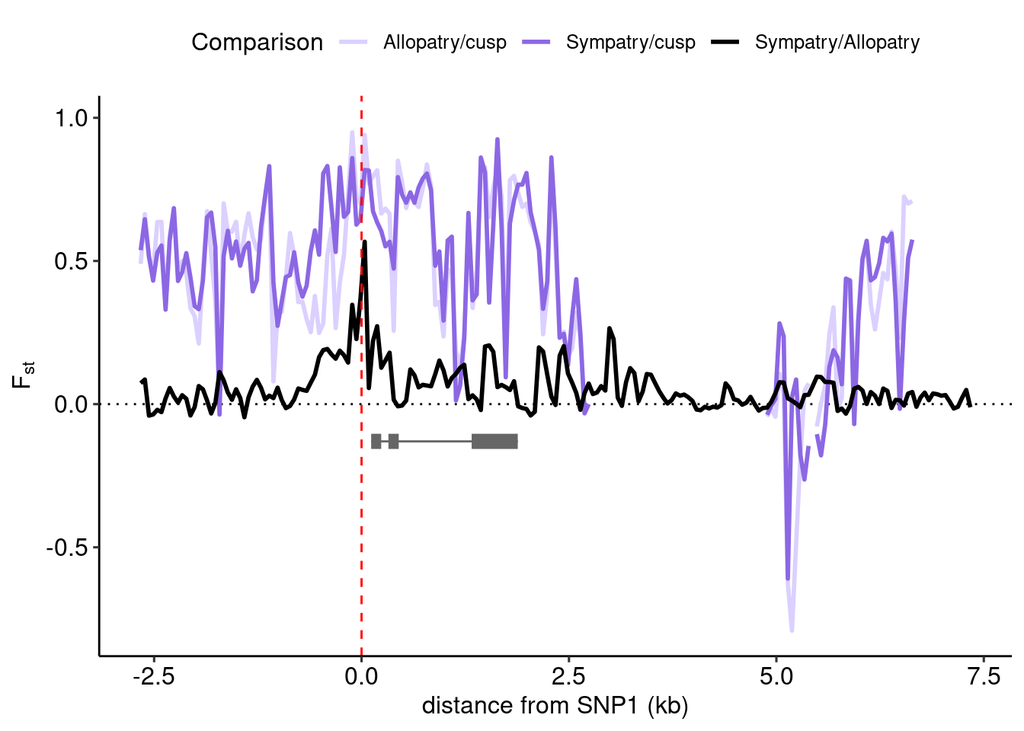

```r
plt_d <- pixy_d[["fst"]] #[no_snps > min_snps[["fst"]]]

# Make comparison names
plt_d[, Comparison := str_c(pop1, "/", pop2)]
plt_d[, Comparison := factor(Comparison, levels=c("Allopatry/cusp", "Sympatry/cusp", "Sympatry/Allopatry"))]

plt_d[, COORDINATE := ScaleCoordinate(chr_position, u=plt_x_units, from_snp=plt_x_from_snp)]

# Group so that lines are not drawn across NA windows
setorder(plt_d, Comparison, START, END)
#plt_d[, LINEGRP := str_c(Comparison[1], GroupLines(avg_wc_fst)), by=Comparison]
#plt_d <- plt_d[!is.na(avg_wc_fst)]

use_col <- allosymp_color
names(use_col) <- str_c(names(use_col), "/cusp")
x <- as.vector(plt_d[pop1 != "cusp" & pop2 != "cusp", Comparison][1])
use_col[x] <- "#000000"

p <- ggplot(plt_d, aes(x = COORDINATE, y = avg_wc_fst, color = Comparison)) +
    geom_hline(yintercept=0, color="black", linetype="dotted") +
    geom_line(size = line_size) +
    xlab(pos_xlab) +
    ylab(bquote(F[st])) +
    theme_pubr() +
    scale_color_manual(values = use_col)
if(plt_x_from_snp){
    p <- p + xlim(rev(plt_xlim))
} else {
    p <- p + scale_x_reverse(limits=rev(plt_xlim))
}

p <- AnnotateGene(p, y=-0.13, u=plt_x_units, from_snp=plt_x_from_snp, exon_col=exon_col)

p_fst <- p
print(p_fst)
```

## Pi subplot

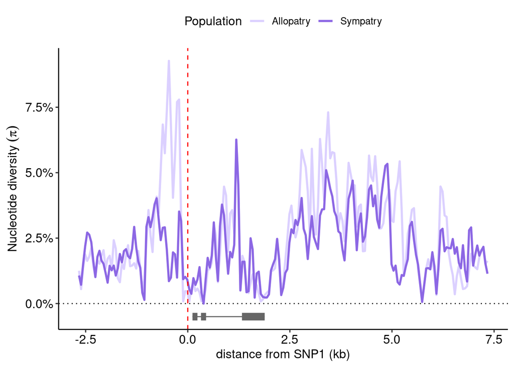

```r
plt_d <- pixy_d[["pi"]][pop %in% names(allosymp_color)] #[no_snps > min_snps[["fst"]]]
setnames(plt_d, "pop", "Population")

# Group so that lines are not drawn across NA windows
setorder(plt_d, Population, START, END)
#plt_d[, LINEGRP := str_c(Population, GroupLines(avg_pi)), by=Population]
#plt_d <- plt_d[!is.na(avg_pi)]

plt_d[, COORDINATE := ScaleCoordinate(chr_position, u=plt_x_units, from_snp=plt_x_from_snp)]

p <- ggplot(plt_d, aes(x = COORDINATE, y = avg_pi, color = Population)) +
    geom_hline(yintercept=0, color="black", linetype="dotted") +
    geom_line(size = line_size) +
    xlab(pos_xlab) +
    scale_y_continuous(labels = scales::percent) +
    ylab(bquote("Nucleotide diversity" ~ (pi))) +
    theme_pubr() +
    scale_color_manual(values = allosymp_color)
if(plt_x_from_snp){
    p <- p + xlim(rev(plt_xlim))
} else {
    p <- p + scale_x_reverse(limits=rev(plt_xlim))
}

p <- AnnotateGene(p, y=-0.005, u=plt_x_units, from_snp=plt_x_from_snp, exon_col=exon_col)

p_pi <- p
print(p_pi)
```

## Tajima’s D and Fay and Wu’s H subplots

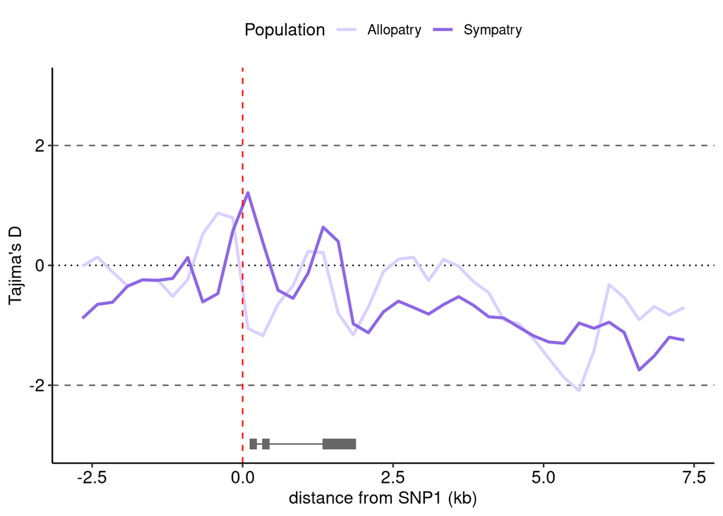

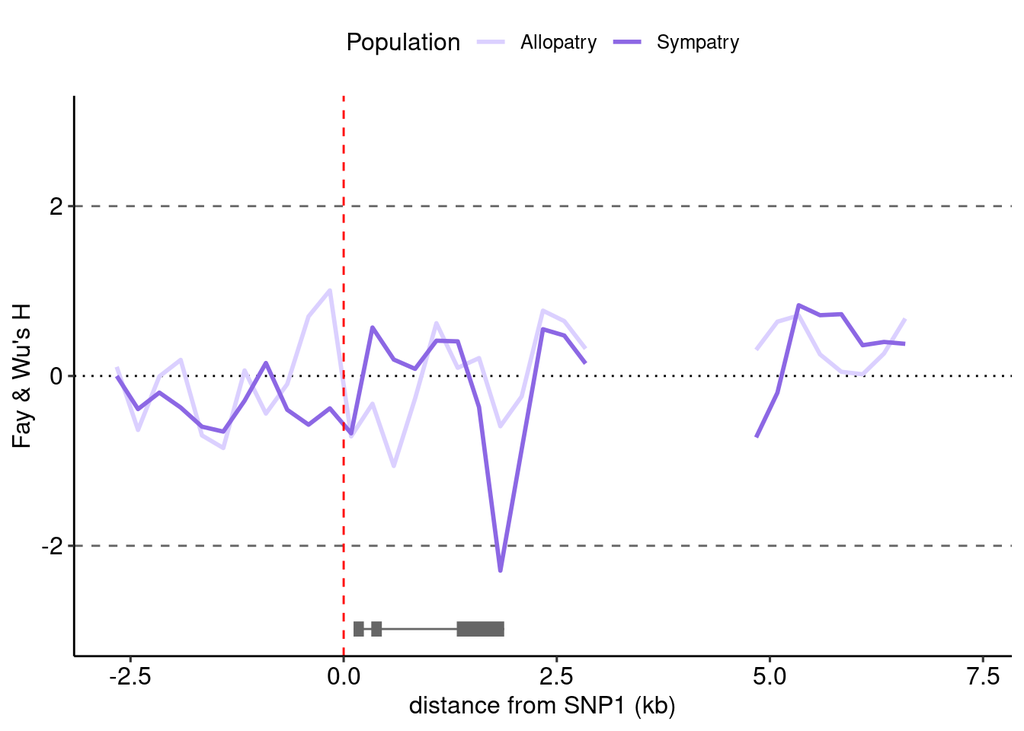

```r
# meas_vars <- c("TAJIMA_D"="Tajima's D", "FAY_WU_H"="Fay & Wu's H")

plt_d <- list()
for(reg in names(allosymp_color)){
    tmp <- list()
    tmp[["TAJ"]] <- sfs_res[["F"]][[reg]][, .(START, END, value=TAJIMA_D, statistic_name="Tajima's D", Population=reg)]
    tmp[["FAY"]] <- sfs_res[["T"]][[reg]][, .(START, END, value=FAY_WU_H, statistic_name="Fay & Wu's H", Population=reg)]
    plt_d[[reg]] <- rbindlist(tmp)
    # plt_d[[reg]] <- melt(   sfs_res[[reg]],
    #                         id.vars=c("START", "END"),
    #                         measure.vars=names(meas_vars),
    #                         value.name="value", variable.name="statistic_name")
    # plt_d[[reg]][, Population := reg]
}
plt_d <- rbindlist(plt_d)
plt_d[, chr_position := ScaleCoordinate((START + END) / 2, u=plt_x_units, from_snp=plt_x_from_snp)]
# plt_d[statistic_name == "TAJIMA_D", statistic_name := meas_vars["TAJIMA_D"]]
# plt_d[statistic_name == "FAY_WU_H", statistic_name := meas_vars["FAY_WU_H"]]

p_sfs <- list()
for(v in unique(plt_d[, statistic_name])){
    # v <- meas_vars[nm]
    p <- ggplot(plt_d[statistic_name == v], aes(x = chr_position, y = value, color = Population))
    p <- AnnotateStdDev(p) +
        geom_line(size = line_size) +
        xlab(pos_xlab) +
        ylab(v) +
        theme_pubr() +
        scale_color_manual(values = allosymp_color) +
        ylim(-3,3)
    if(plt_x_from_snp){
        p <- p + xlim(rev(plt_xlim))
    } else {
        p <- p + scale_x_reverse(limits=rev(plt_xlim))
    }

    p <- AnnotateGene(p, u=plt_x_units, from_snp=plt_x_from_snp, exon_col=exon_col)

    nm <- substr(v, 1, 3)
    p_sfs[[nm]] <- p
    print(p_sfs[[nm]])
}
```

## LD subplot

Prep data

```r
zoom_width <- 2e3
plt_stat <- "MEAN"
color_scale <- "limited"

ymin_zoom <- snp_pos - (snp_pos %% binwidth) - zoom_width/2
ymax_zoom <- snp_pos - (snp_pos %% binwidth) + zoom_width/2 + binwidth

p_ld <- list()
for(zoomed in c(FALSE, TRUE)){
    if(zoomed){
        ymin <- ymin_zoom
        ymax <- ymax_zoom
    } else {
        ymin <- min(ld_aggr[["POS_Y"]])
        ymax <- max(ld_aggr[["POS_Y"]]) + 10*binwidth
    }

    p <- ggplot()

    # Draw gene body
    gene_range <- gene_d[ELEMENT != "promoter", sort(range(c(START, END)))]
    gene_range[gene_range < ymin] <- ymin
    gene_range[gene_range > ymax] <- ymax
    p <- p + annotate("line", x=gene_range, y=rep(ymax, 2), color=exon_col, linewidth=ifelse(zoomed, 2/7, 3/7))
    for(i in 1:nrow(gene_d)){
        if(gene_d[i, ELEMENT] == "promoter"){ next }
        reg <- as.numeric(gene_d[i, c(START+1, END)])
        reg[reg < ymin] <- ymin
        reg[reg > ymax] <- ymax

        p <- p + annotate("line", x=reg, y=rep(ymax, 2), color=exon_col, linewidth=ifelse(zoomed, 2, 3))
    }
    # Annotate snp
    arrow_len <- ifelse(zoomed, 120, 600)
    p <- p + annotate("segment", x=snp_pos, xend=snp_pos, y=ymax+arrow_len*0.7, yend=ymax-arrow_len*0.3, arrow=arrow(length=unit(0.07, "inches")), color="red")

    if(zoomed){
        cur_plt <- ld_aggr[(POS_Y >= ymin) & (POS_Y <= (ymax - binwidth)) & (POS_X >= ymin) & (POS_X <= (ymax - binwidth))]
        use_guide <- "none"
    } else {
        cur_plt <- ld_aggr[1:.N]
        use_guide <- guide_colorbar(title=bquote("Mean" ~ r^2), barwidth=unit(2, "inches"), draw.ulim=FALSE, draw.llim=FALSE)
    }
    p <- p + geom_tile(aes(x=POS_X, y=POS_Y, fill=.data[[plt_stat]]), data=cur_plt)

    if(color_scale == "linear"){
        p <- p +
            scale_fill_gradient(low=lo_color, high=hi_color,
                                breaks=c(0, 0.25, 0.5, 0.75, 1.0),
                                limits=c(0, 1),
                                guide=use_guide)
    } else if(color_scale == "log"){
        p <- p +
            scale_fill_gradient(low=lo_color, high=hi_color,
                                trans=scales::pseudo_log_trans(sigma=0.001),
                                breaks=c(0, 0.01, 0.1, 1.0),
                                limits=c(0, 1),
                                guide=use_guide)

    } else if(color_scale == "limited"){
        p <- p +
            scale_fill_gradient(low=lo_color, high=hi_color,
                                breaks=c(0, 0.1, 0.2, 0.3, 0.4, 0.5),
                                labels=c("0", "0.1", "0.2", "0.3", "0.4", "> 0.5"),
                                limits=c(0, 0.5),
                                guide=use_guide)
    }

    if(zoomed){
        p <- p +
            scale_x_reverse() +
            scale_y_reverse() +
            guides(y.sec="axis") +
            theme(  axis.title.x=element_blank(),
                    axis.text.x=element_blank(),
                    axis.ticks.x=element_blank(),
                    axis.line.x.top=element_blank(),
                    axis.line.x.bottom=element_line(color="black", linewidth=1, lineend="round"),
                    axis.title.y=element_blank(),
                    axis.text.y=element_blank(),
                    axis.ticks.y=element_blank(),
                    axis.line.y.left=element_blank(),
                    axis.line.y.right=element_line(color="black", linewidth=1, lineend="round"),
                    panel.background=element_blank(),
                    plot.background=element_blank())
    } else {
        if(plt_x_from_snp){
            use_breaks <- snp_pos + seq(10, -12, by=-2) * 1e3
        } else {
            use_breaks <- c(22290000, 22295000, 22300000, 22305000, 22310000)
        }
        use_labels <- ScaleCoordinate(use_breaks, u=plt_x_units, from_snp=plt_x_from_snp)

        p <- p +
            scale_x_continuous(name=pos_xlab, breaks=use_breaks, labels=use_labels, trans="reverse") +
            scale_y_continuous(name=pos_xlab, breaks=use_breaks, labels=use_labels, trans="reverse") +
            annotate("path",
                      x=c(ymin_zoom, ymin_zoom, ymax_zoom),
                      y=c(ymin_zoom, ymax_zoom, ymax_zoom),
                      color="black", linewidth=0.8) +
            theme_pubr()
    }

    p_ld[[ifelse(zoomed, "zoom", "full")]] <- p
}
```

Plot with inset

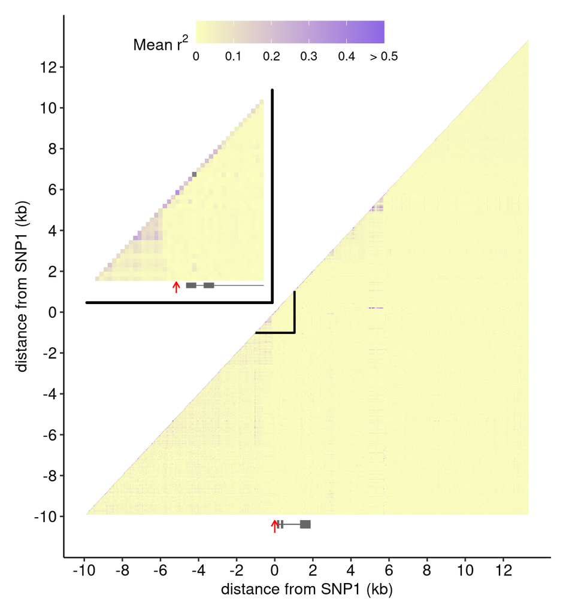

```r
# subvp <- viewport(width=0.35*1.2, height=0.31*1.2, x=0.35, y=0.65)
# print(p_ld[["full"]])
# print(p_ld[["zoom"]], vp=subvp)

print(  p_ld[["full"]] + theme(legend.position = c(0.4, 0.95), legend.direction = "horizontal") +
        inset_element(p_ld[["zoom"]], left=0.025, bottom=0.45, right=0.45, top=0.875) )
```

## EHH subplots

EHH traces of derived vs ancestral allele at putative SNP pos

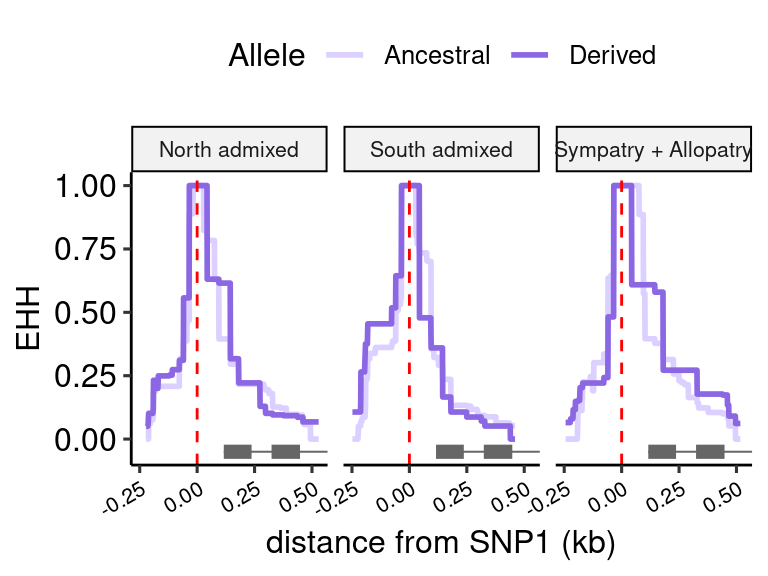

```r
use_col <- c()
use_col["Ancestral"] <- allosymp_color["Allopatry"]
use_col["Derived"]   <- allosymp_color["Sympatry"]

use_reg <- c("symp_allo", "North_admix", "South_admix")

use_xlim <- range(unlist(lapply(ehh_sub[use_reg], function(x) range(x$ehh$POSITION))))
use_xlim <- ScaleCoordinate(use_xlim, u=plt_x_units, from_snp=plt_x_from_snp)
if(plt_x_from_snp){
    use_breaks <- seq(0.5, -0.25, by=-0.25)
} else {
    use_breaks <- seq(ceiling(use_xlim[1] * 1e4), floor(use_xlim[2] * 1e4), length.out=4) / 1e4
}

plt_d <- list()
for(reg in use_reg){
    reg_nm <- ifelse(reg == "symp_allo",
                    "Sympatry + Allopatry",
                    str_replace(reg, "_admix", " admixed"))
    plt_d[[reg]] <- melt(as.data.table(ehh_sub[[reg]][["ehh"]]),
                id.vars=c("POSITION", "NHAPLO_A", "NHAPLO_D"), measure.vars=c("EHH_A", "EHH_D"),
                variable.name="VARIABLE", value.name="VALUE")
    plt_d[[reg]][, REGION := reg_nm]
}

plt_d <- rbindlist(plt_d)

plt_d[, POSITION := ScaleCoordinate(POSITION, u=plt_x_units, from_snp=plt_x_from_snp)]
plt_d[VARIABLE == "EHH_A", Allele := "Ancestral"]
plt_d[VARIABLE == "EHH_D", Allele := "Derived"]


p <- ggplot(plt_d, aes(x=POSITION, y=VALUE, color=Allele)) +
    geom_line(size=1) +
    scale_color_manual(values=use_col) +
    xlab(pos_xlab)
if(plt_x_from_snp){
    p <- p + scale_x_continuous(breaks=use_breaks)
} else {
    p <- p + scale_x_reverse(breaks=use_breaks)
}
p <- p +
    coord_cartesian(xlim=rev(use_xlim)) +
    ylab("EHH") +
    facet_wrap(vars(REGION), nrow=1) +
    theme_pubr(x.text.angle=30) +
    theme(axis.text.x=element_text(size=8),
          strip.text.x=element_text(size=8))
p <- AnnotateGene(p, y=-0.05, w=2.5, u=plt_x_units, from_snp=plt_x_from_snp, exon_col=exon_col)

p_ehh <- p
print(p_ehh)
```

## XP-EHH subplot

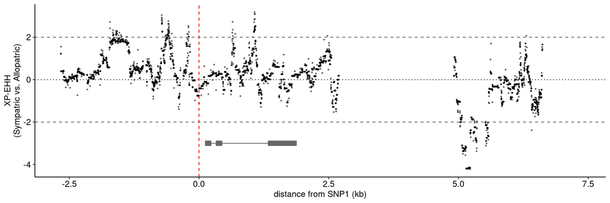

```r
xpehh_sym_allo[, COORDINATE := ScaleCoordinate(POSITION, u=plt_x_units, from_snp=plt_x_from_snp)]
p <- ggplot(xpehh_sym_allo, aes(x=COORDINATE, y=XPEHH_SYMP_ALLO)) +
    geom_point(size=0.5, alpha=0.5) +
    xlab(pos_xlab)

if(plt_x_from_snp){
    p <- p + xlim(rev(plt_xlim))
} else {
    p <- p + scale_x_reverse(limits=rev(plt_xlim))
}

p <- p + scale_y_continuous(name="XP-EHH\n(Sympatric vs. Allopatric)", breaks=seq(-4, 4, by=2)) +
    theme_pubr()

p <- AnnotateStdDev(p)
p <- AnnotateGene(p, y=-3, u=plt_x_units, from_snp=plt_x_from_snp, exon_col=exon_col)
print(p)
```

```r
p_xpehh <- p
```

# Final plotting

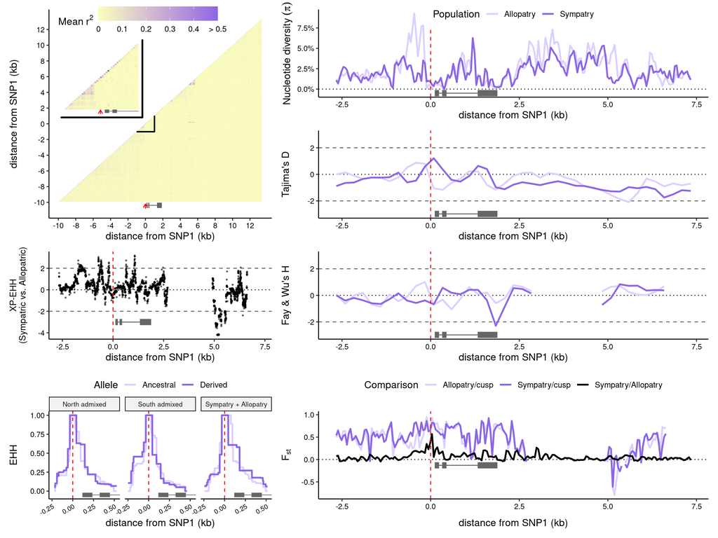

```r
des <- "
AAAADDDDDDD
AAAAEEEEEEE
BBBBFFFFFFF
CCCCGGGGGGG
"

pA <- p_ld[["full"]] + #ggtitle("A") +
    theme(legend.position = c(0.4, 0.95), legend.direction = "horizontal",
        text=element_text(family="Helvetica"), axis.text=element_text(size=9))
pB <- p_xpehh + #ggtitle("B") +
    theme(text=element_text(family="Helvetica"),
        axis.text=element_text(size=9), axis.title.y=element_text(size=10.5))

pC <- p_ehh + #ggtitle("C") +
    theme(legend.box.spacing=unit(0, "pt"), text=element_text(family="Helvetica"),
        axis.text=element_text(size=9))

pD <- p_pi + #ggtitle("D") +
    theme(legend.position = c(0.5, 0.95), legend.direction = "horizontal",
        text=element_text(family="Helvetica"), axis.text=element_text(size=9))
pE <- p_sfs[["Taj"]] + #ggtitle("E") +
    theme(legend.position="none",
        text=element_text(family="Helvetica"), axis.text=element_text(size=9))
pF <- p_sfs[["Fay"]] + #ggtitle("F") +
    theme(legend.position="none",
        text=element_text(family="Helvetica"), axis.text=element_text(size=9))
pG <- p_fst + #ggtitle("G") +
    theme(legend.box.spacing=unit(0, "pt"),
        text=element_text(family="Helvetica"), axis.text=element_text(size=9))
# + theme(legend.position = c(0.5, 1.37), legend.direction = "horizontal",
#                     legend.background=element_blank(), legend.box.background=element_blank())

p_full <- pA + inset_element(p_ld[["zoom"]], left=0.025, bottom=0.45, right=0.45, top=0.875) +
    pB + pC + pD + pE + pF + pG +
    plot_layout(design=des)
print(p_full)
```

```r
ggsave(p_full, filename="figure4.pdf", height=9, width=12)
```